[figure not shown]

[figure not shown]

Original Research

The translation of surgical animal models to human clinical research: A

cross-sectional study

Yongle Ruan<sup>1</sup>, N. Bryce Robinson<sup>1</sup>, Faiza M. Khan, Irbaz Hameed, Mohamed Rahouma,

Ajita Naik, Christian T. Oakley, Lisa Rong, Leonard N. Girardi, Mario Gaudino<sup>∗</sup>

Department of Cardiothoracic Surgery, Weill Cornell Medical Center, 535 E 68th Street, New York, NY, 10065, USA

A R T I C L E I N F O

Keywords:

Animal models

Basic science

Human/clinical research

A B S T R A C T

Background: Surgical animal models are used in pre-clinical scientiﬁc studies. To date there has not been an

analysis of how eﬀective these data are when translated to human/clinical research. In this retrospective review,

we evaluate the impact of studies using surgical animal models on human/clinical research through study-level

analysis of citations.

Methods: The top two ranking clinical journals based on impact factor for the top ten surgical specialties were

identiﬁed and a search was run on PubMed to identify studies using surgical animal models published in the

years 2007 and 2008. The translation to human/clinical research of each study was evaluated by analyzing the

frequency of citation in human studies over the ten years following publication. Regression was used to identify

predictors of citation in human/clinical research.

Results: 411 animal studies using surgical models were identiﬁed. Over the course of the 10 years following

publication the original animal studies were cited 6063 times, with 1300 (21.4%) citations in human/clinical

studies and 4763 (78.6%) in animal/basic science studies. The median number of citations in human/clinical

research was 1 (IQR 0–5). Regression showed an association between citation in human/clinical research and the

use of porcine models and the specialties of general surgery, oral and maxillofacial surgery, orthopedic surgery,

transplant, and plastic surgery.

Conclusion: The use of animal models in surgical research shows poor translation to human/clinical research.

Alternative surgical models should urgently be explored.

1. Introduction

Traditionally, animals have been used as models for investigation in

medicine, but the clinical relevance of knowledge gained from animal

studies has been repeatedly questioned [1–3]. Animal studies often

have methodological ﬂaws that jeopardize translation to human/clin-

ical research [2]. Methods to evaluate animal research and guidelines

for the conduct and reporting of animal studies have been developed to

address these concerns [2,3].

Animal models may be particularly useful to test surgical proce-

dures before human application. Inter-species diﬀerences at the mole-

cular or genetic level are less relevant in surgical studies due to the

focus on anatomic similarities. One of the earliest and most clinically

successful examples of the use of a surgical animal model was the de-

velopment of the tracheostomy procedure through testing on goats by

Ibn Zuhr in the 12th century [4]. Other examples that advanced the

ﬁeld of surgery include the experimental work on dogs in the 1900s by

Georg Kelling, which set the platform for modern day laparoscopy, and

by Vivien Thomas and Alfred Blalock, which pioneered the repair of

Fallot's tetralogy [5,6]. However, the current surgical era focuses on the

reﬁnement and standardization of established procedures more than on

the introduction of new techniques and, for ethical and scientiﬁc rea-

sons, the role of surgical animal models requires an objective re-eva-

luation.

In this study, we sought to objectively evaluate the translation to

human/clinical research of studies employing surgical animal models

by analyzing the frequency of their citation amongst human studies

over the 10 years following publication.

∗ Corresponding author. Department of Cardiothoracic Surgery, Weill Cornell Medicine, 525 E 68th St, New York, NY, 10065, USA.

E-mail address: mfg9004@med.cornell.edu (M. Gaudino).

1 Equal contribution.

2. Methods

2.1. Journal and study selection

The top two ranking clinical journals based on impact factor for the

top ten surgical specialties (cardiac and thoracic surgery, general sur-

gery, neurosurgery, obstetrics and gynecology, oral and maxillofacial

surgery, orthopedic surgery, plastic surgery, transplant, urology, and

vascular surgery) were identiﬁed on Google Scholar Metrics [7] and a

search was run on PubMed to identify studies using surgical animal

models published in the years 2007 and 2008. This returned 1631 re-

sults. The detailed search strategy is presented in the Supplementary

Appendix. Three independent reviewers (B.R., I.H, and A.N.) manually

screened the 1631 studies to identify surgical animal model studies and

disagreements were resolved by a fourth author (M.G.). Articles were

considered for inclusion if they were written in English and were con-

ducted utilizing in-vivo surgical procedures using animal models. Stu-

dies that did not clearly describe a surgical intervention, involved an-

imal cell and tissue cultures for basic research, in-vitro, ex-vivo, organ

harvesting, and surgical maneuvers related for physiologic changes

were excluded. Citations in case reports, conference presentations,

editorials, letters, and expert opinions were also excluded. This work

has been reported in line with the Strengthening the Reporting of Co-

hort Studies in Surgery (STROCSS) criteria [8].

Each included article was searched on Web of Science to identify the

total number of citations from 2007 to 2018 and the year of citation

[9]. The citations were manually assessed by two reviewers (Y.R. and

I.H.). They were then classiﬁed as “human/clinical” if they reported a

clinical observational study or randomized controlled trial involving

human patients or “animal/basic science” if they described basic sci-

ence research involving animals or cell/tissue-level experiments. For

each included article, the following data were recorded: the surgical

animal model studied, surgical specialty, subgroup (device vs. outcome

vs. technique), outcome (positive vs. negative vs. neutral), and journal

of publication.

2.2. Statistical analysis

Categorical data are presented as frequency and percentages, and

continuous data are presented as median and inter-quartile range (IQR)

Multiple regression was performed to identify any predictors of ci-

tation in human/clinical research amongst the variables of surgical

specialties and diﬀerent animal models used. P-value < 0.05 was con-

sidered statistically signiﬁcant. All analyses were performed using R

(version 3.4.2 R Project for Statistical Computing) within RStudio.

3. Results

A total of 21,413 articles were published in the 20 chosen journals

between January 2007 and December 2008 (Tables 1 and 3). Of these,

411 (1.9%) involved surgical animal models and were eligible for

analysis. There were 178 (43.3%) device-related studies, 142 (34.5)

outcomes studies, and 91 (22.1) surgical technique studies. Study out-

comes were mostly positive (n = 343, 83.5%) Table 2. A majority of the

studies utilized mouse models (212 [51.6%]), while monkey/primate

models were used less frequently (9 [2.2%]). Details of the surgical

animal models used are presented in Table 4.

Surgical animal model studies were cited in a total of 6063 times

between 2007 and 2018. Among them, 1300 (21.4%) citations were in

human/clinical studies and 4763 (78.6%) were in animal/basic science

studies (Table 3). Fig. 1 summarizes the frequency of surgical animal

model study citations in human/clinical and animal/basic science ar-

ticles.

The median number of citations in human/clinical and animal/basic

science articles was 1 (IQR 0–5) and 8 (IQR 4–17), respectively

(p < 0.001, Fig. 2). The annual number of citations in human/clinical

articles were signiﬁcantly lower than in animal/basic science articles

(p < 0.001), reaching a peak in 2011 (Fig. 3).

On multivariable analysis, studies in the ﬁelds of general surgery,

oral and maxillofacial surgery, orthopedic surgery, transplant, and

plastic surgery, as well as the use of a porcine model were signiﬁcantly

associated with citation in human/clinical research articles. Studies

describing a surgical technique were signiﬁcantly less likely to be cited

in a subsequent human/clinical research article. (Table 5).

4. Discussion

We found that the translation of results from surgical animal studies

median number of citations in human articles was one. Studies invol-

ving the surgical specialties of OMFS, general surgery, plastic surgery,

orthopedic surgery, and transplantation were more likely to have a

Table 1

Number of studies using surgical animal models from 2007 to 2008 by surgical

specialty and top two highest impact journals within each specialty.

Specialty and Journal

Number of studies (%)<sup>a</sup>

Gynecology & Obstetrics

8 (1.9)

• <sup>American Journal of Obstetrics & Gynecology</sup>

7 (1.7)

• <sup>Obstetrics & Gynecology</sup>

1 (0.2)

Heart & Thoracic Surgery

112 (27.3)

• <sup>Journal of Thoracic and Cardiovascular Surgery</sup>

76 (18.5)

• <sup>Annals of Thoracic Surgery</sup>

36 (8.8)

Neurosurgery

19 (4.6)

• <sup>Neurosurgery</sup>

18 (4.4)

• <sup>Journal of Neurosurgery</sup>

1 (0.2)

Oral & Maxillofacial Surgery

11 (2.7)

• <sup>Clinical Implant Dentistry and Related Research</sup>

10 (2.4)

• <sup>International Journal of Oral & Maxillofacial Implants</sup>

1 (0.2)

Orthopedic Medicine & Surgery

43 (10.5)

• <sup>Clinical Orthopaedics and Related Research</sup>

24 (5.8)

• <sup>The Journal of Bone & Joint Surgery</sup>

19 (4.6)

Plastic

87 (21.2)

• <sup>Plastic and Reconstructive Surgery</sup>

49 (11.9)

• <sup>Journal of Plastic, Reconstructive, & Aesthetic Surgery</sup>

38 (9.2)

Surgery

28 (6.8)

• <sup>Annals of Surgery</sup>

18 (4.4)

• <sup>British Journal of Surgery</sup>

10 (2.4)

Transplantation

31 (7.5)

• <sup>American Journal of Transplantation</sup>

16 (3.9)

• <sup>The Journal of Heart and Lung Transplantation</sup>

15 (3.6)

Urology & Nephrology

36 (8.8)

• <sup>The Journal of</sup><sup>Urology</sup>

29 (7.1)

• <sup>European Urology</sup>

7 (1.7)

Vascular Medicine

36 (8.8)

• <sup>Journal of Vascular Surgery</sup>

27 (6.6)

• <sup>European Journal of Vascular and Endovascular</sup>

Surgery

9 (2.2)

Citation of Human clinical Research (median [IQR])

1 [0, 5]

Citation of original basic Research (median [IQR])

8 [4,17]

a Percentages were calculated per specialty and journal separately.

Table 2

Article outcomes and subtype.

Outcome

Number of studies (%)

• <sup>Positive</sup>

343 (83.5)

• <sup>Neutral</sup>

56 (13.6)

• <sup>Negative</sup>

12 (2.9)

Subgroup

• <sup>Devices</sup>

178 (43.3)

• <sup>Outcomes</sup>

142 (34.5)

• <sup>Technique</sup>

91 (22.1)

subsequent citation in human/clinical research. Notably, papers de-

scribing techniques were less likely to be cited.

While internal validity is a key area for improvement in animal

studies, external validity due to biomolecular dissimilarities between

species is the most important factor that limits translation to human

research [10–13]. In surgical studies, however, animal models are

chosen for similarity to gross human anatomy and molecular or genetic

diﬀerences may play a more limited role [13,14].

Our results are consistent with previous data in showing very poor

translation of surgical animal studies to human research [15]. We

speculate that, in the modern surgical era, there is a focus on reﬁning

techniques and outcomes rather than introducing new surgical proce-

dures, and the use of anatomic analogues is not enough to achieve re-

sults that can be translated into human research [4]. As an example,

obtaining long-term follow-up or imaging data is diﬃcult in animal

models, but it is key to achieve meaningful research results in surgery

[2].

Clinical translation is one of the primary justiﬁcations for the

Table 3

Citations of studies using surgical animal models over the course of 10 years.

Surgical Specialty

Total number of publications in the

top two journals for each specialty

(2007–2008)

% of publications

involving SAMs

Citations (2007–2018)

Total number of

eligible citations of

SAM studies

% of citations in human/

clinical studies (n = 1300)

% of citations in animal/

basic science studies

(n = 4763)

Cardiac and Thoracic

Surgery

3556

3.1

1307

22.8

77.2

General Surgery

1222

2.3

826

24.7

75.3

Neurosurgery

2230

0.9

286

16.1

83.9

Obstetrics and Gynecology

2369

0.3

66

22.7

77.3

Oral and Maxillofacial

Surgery

353

3.1

245

19.2

80.8

Orthopedic Surgery

2065

2.1

1239

18.6

81.4

Plastic Surgery

2973

2.9

360

14.7

85.3

Transplant

1321

2.3

706

22.1

77.9

Urology

3721

1.0

591

25.0

75.0

Vascular Surgery

1603

2.2

437

23.3

76.7

TOTAL

21,413

1.9

6063

21.4

78.6

Table 4

Frequency of surgical animal models.

Surgical animal model

Frequency in studies

Chicken/sheep/lamb/horses

48 (11.7)

Dogs

50 (12.2)

Mice

212 (51.6)

Monkeys/primates

9 (2.2)

Pigs

92 (22.4)

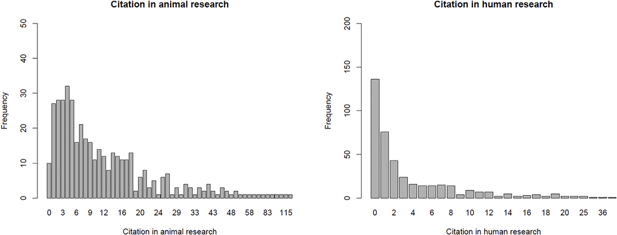

Fig. 1. Frequency of citations in animal/basic science and human/clinical articles.

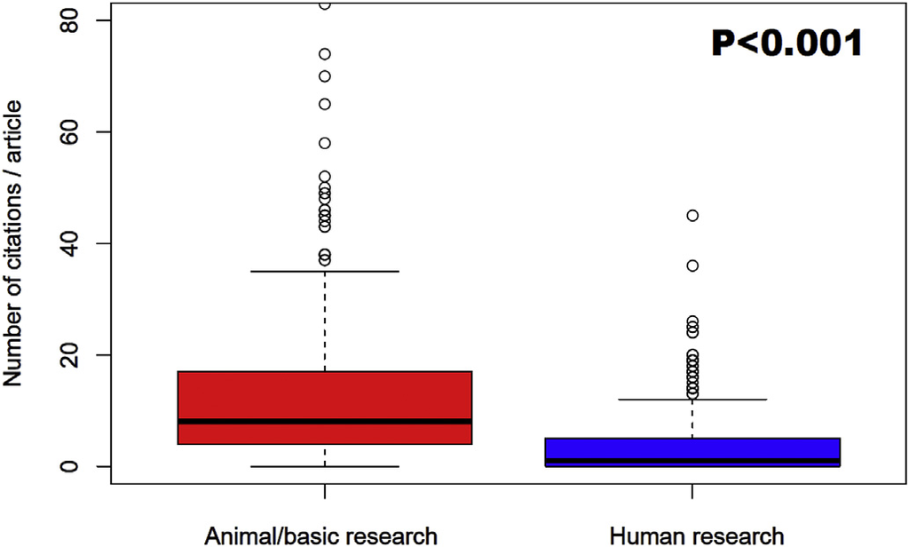

articles.

Interpretation: upper horizontal line of box, 75th percentile; lower horizontal

line of box, 25th percentile; thick horizontal bar within box, median; upper

horizontal bar outside box, 90th percentile; lower horizontal bar outside box,

10th percentile. Circles represent outliers.

continued use of surgical animal models. The limitations in the trans-

lation of surgical animal model studies to human research, the un-

necessary suﬀering of the animals involved, and the wasted ﬁnancial

resources raise questions of a moral and ethical nature. Simulation

models are an alternative medium gaining popularity for surgical re-

search and may represent a more ethical and eﬀective approach [13].

To be sure, animal models have provided signiﬁcant contributions

in the advancement of medicine. Novel procedures and medications are

routinely trialed on animal models in pre-clinical trials. In the modern

era, however, practical and ethical concerns have led some to question

the continued use of animals in research. In a recent analysis of cancer

literature, for example, it was found that less than 8% of pre-clinical

studies translated to human clinical trials [16]. Until better translation

is noted, alternatives should be explored in the pre-clinical setting.

Several limitations of this review need to be considered. Firstly, our

review did not individually evaluate surgical animal studies for meth-

odology. This makes it diﬃcult to accurately predict whether faulty

methodology may have been one of the factors that hindered clinical

translation. Additionally, we only used Web of Science to identify ci-

tations so it is possible that some citations present in other databases

may have been missed. The method of using citation counts to estimate

research impact itself is controversial with a known restriction of time

needed for citation accruement [17]. We tried to compensate for this by

reviewing studies published ten years prior. Additionally, we did not

capture whether a subsequent human citation was the foundation for

further studies, rendering the original animal citation more clinically

important. Finally, we only analyzed studies in the top surgical journals

making clinical translation more likely than studies published in less

well-known journals. Unfortunately, this suggests that there are even

lower rates of translation from animal research to clinically signiﬁcant

human advancement.

5. Conclusion

Our study provides essential insights on the usefulness of animal

models in surgical research in the contemporary era and suggests that

results from animal models are poorly translated into human/clinical

research. Surgical model alternatives to animals should be urgently

explored.

Ethical approval

Ethical approval was not required.

Sources of funding

There were no sources of funding for this research project.

Author contribution

All authors listed have made contributions to the review. NBR and

MG designed the study. NBR, YR, FMK, IH, MR, AN, CTO, LR, LNG, and

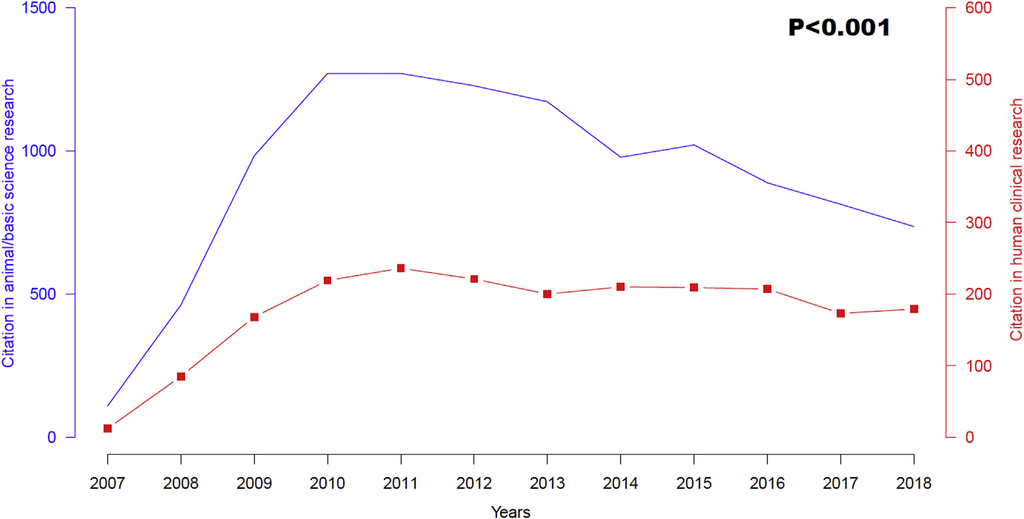

Fig. 3. Annual number of citations in animal/basic science versus human/clinical research. The annual number of citations in human/clinical studies were sig-

niﬁcantly lower than in animal/basic science studies (p < 0.001, Chi square test).

Table 5

Predictors of citations in human/clinical research.

Variable

Regression coeﬃcient (beta) (95%

conﬁdence interval)

Surgical specialty (vs Cardiac and Thoracic

Surgery) ¶

• <sup>Gynecology/Obstetrics</sup>

−0.26 (−0.84, 0.32)

• <sup>Neurosurgery</sup>

−0.18 (−0.52, 0.16)

• <sup>Oral Maxillofacial Surgery</sup>

0.67*** (0.33, 1.00)

• <sup>Orthopedic Surgery</sup>

0.62*** (0.43, 0.80)

• <sup>Plastic</sup>

0.40*** (0.22, 0.58)

• <sup>Surgery</sup>

0.76*** (0.56, 0.95)

• <sup>Transplantation</sup>

0.46*** (0.25, 0.68)

• <sup>Urology Nephrology</sup>

0.25** (0.04, 0.46)

• <sup>Vascular surgery</sup>

−0.14 (−0.38, 0.10)

Surgical animal model (vs Dogs)

• <sup>Pigs</sup>

0.47*** (0.25, 0.70)

• <sup>Chicken/sheep/lamb/horse</sup>

0.59*** (0.35, 0.82)

• <sup>Mice</sup>

0.51*** (0.29, 0.72)

• <sup>Monkeys/primates</sup>

0.52*** (0.16, 0.89)

Outcome (vs Negative)

• <sup>Neutral</sup>

0.30 (−0.14, 0.74)

• <sup>Positive</sup>

0.25 (−0.17, 0.66)

Subgroup (vs Device)

• <sup>Outcome</sup>

0.02 (−0.11, 0.15)

• <sup>Technique</sup>

−0.27*** (−0.42, −0.11)

¶ Cardiac and Thoracic Surgery was used as a reference as it has the highest

number of included studies.

*p < 0.1; **p < 0.05; ***p < 0.01.

MG participated in collecting the data, analysing the data, drafting the

manuscript, revising the manuscript. All authors read the ﬁnal manu-

script and approved it.

Trial registry number

Name of the registry: Not applicable.Unique Identifying number or

registration ID: Not applicable.Hyperlink to the registration (must be

publicly accessible): Not applicable.

Guarantor

Mario Gaudino MD, corresponding author.

Provenance and peer review

Not commissioned, externally peer-reviewed.

Abbreviations

None.

Data statement

The data obtained in this study can be made available upon request.

CRediT authorship contribution statement

Yongle Ruan: Writing - original draft, Data curation. N. Bryce

Robinson: Writing - original draft, Conceptualization, Methodology,

Data

curation.

draft,

Conceptualization, Methodology. Irbaz Hameed: Writing - original

draft, Data curation. Mohamed Rahouma: Writing - original draft.

Ajita Naik: Writing - original draft, Data curation. Christian T.

Oakley: Writing - original draft, Data curation. Lisa Rong: Writing -

original draft. Leonard N. Girardi: Writing - original draft. Mario

Gaudino: Writing - original draft, Conceptualization, Methodology.

Declaration of competing interest

The authors have no conﬂicts of interest.

Acknowledgements

The authors have no acknowledgements to make.

Appendix A. Supplementary data

Supplementary data to this article can be found online at https://

doi.org/10.1016/j.ijsu.2020.03.023.

References

[1] A.C. Ericsson, M.J. Crim, C.L. Franklin, A brief history of animal modeling, Mo.

Med. 110 (2013) 201–205.

[2] P. Pound, S. Ebrahim, P. Sandercock, M.B. Bracken, I. Roberts, Where is the evi-

dence that animal research beneﬁts humans? BMJ 328 (2004) 514–517.

[3] C. Kilkenny, W.J. Browne, I.C. Cuthill, M. Emerson, D.G. Altman, Improving

bioscience research reporting: the ARRIVE guidelines for reporting animal research,

PLoS Biol. 8 (2010), https://doi.org/10.1371/journal.pbio.1000412 e1000412.

[4] F.S. Haddad, Ibn Zuhr and experimental tracheostomy and tracheotomy, J. Am.

Coll. Surg. 199 (2004) 665, https://doi.org/10.1016/j.jamcollsurg.2004.06.015.

[5] G.S. Litynski, Laparoscopy–the early attempts: spotlighting Georg kelling and hans

christian jacobaeus, J. Soc. Laparoendosc. Surg. 1 (1997) 83–85.

[6] S. Timmermans, A black technician and blue babies, Soc. Stud. Sci. 33 (2003)

197–229, https://doi.org/10.1177/03063127030332014.

[7] English - Google Scholar Metrics, n.d https://scholar.google.com/citations?view_

op=top_venues&hl=en (accessed June 20, 2019).

[8] R. Agha, A. Abdall-Razak, E. Crossley, N. Dowlut, C. Iosiﬁdis, G. MathewSTROCSS

Group, STROCSS 2019 Guideline: Strengthening the reporting of cohort studies in

surgery, Int. J. Surg. Lond. Engl. 72 (2019) 156–165, https://doi.org/10.1016/j.

ijsu.2019.11.002.

[9] Web of Science - Web of Science Group, n.d https://clarivate.com/

webofsciencegroup/solutions/web-of-science/ (accessed June 20, 2019).

[10] C. Kilkenny, N. Parsons, E. Kadyszewski, M.F.W. Festing, I.C. Cuthill, D. Fry,

J. Hutton, D.G. Altman, Survey of the quality of experimental design, statistical

analysis and reporting of research using animals, PloS One 4 (2009), https://doi.

org/10.1371/journal.pone.0007824 e7824.

[11] J.L. Fontoura-Andrade, R.F.B. de Amorim, J.B. de Sousa, Improving reproducibility

and external validity. The role of standardization and data reporting of laboratory

rat husbandry and housing, Acta Cir. Bras. 32 (2017) 251–262, https://doi.org/10.

1590/S0102-865020170030000010.

[12] M.B. Bracken, Why animal studies are often poor predictors of human reactions to

exposure, J. R. Soc. Med. 102 (2009) 120–122, https://doi.org/10.1258/jrsm.2008.

08k033.

[13] P. Pound, M. Ritskes-Hoitinga, Is it possible to overcome issues of external validity

in preclinical animal research? Why most animal models are bound to fail, J. Transl.

Med. 16 (2018) 304, https://doi.org/10.1186/s12967-018-1678-1.

[14] P. Pound, M.B. Bracken, Is animal research suﬃciently evidence based to be a

cornerstone of biomedical research? BMJ 348 (2014) g3387, https://doi.org/10.

1136/bmj.g3387.

[15] D.G. Hackam, D.A. Redelmeier, Translation of research evidence from animals to

humans, J. Am. Med. Assoc. 296 (2006) 1731–1732, https://doi.org/10.1001/

jama.296.14.1731.

[16] I.W. Mak, N. Evaniew, M. Ghert, Lost in translation: animal models and clinical

trials in cancer treatment, Am. J. Transl. Res. 6 (2014) 114–118.

[17] J. Wang, Citation time window choice for research impact evaluation,

Scientometrics 94 (2013) 851–872, https://doi.org/10.1007/s11192-012-0775-9.